# Analysis of Variance: One-way ANOVA

Tehran Davis

10/25/2017

In this week’s class we covered **ANOVA**. A major emphasis in the lecture was that ANOVA (much like many of the other tests that we cover in this course) is an extension of the general linear model. In many respects, ANOVA and regression are conceptually identical—whereas in linear regression our predictor variables are typically continuous (or, in some cases ordinal) we usually reserve ANOVA for instances when our predictors are discrete or nominal. This would be the difference say in predicting weight as a function of height (linear regression) in contrast to weight as function of hometown (Dayton, Youngstown, Cleveland, Cincinnati). Given that both the Howell (Chapter 11) and Field (Chapter 10) do a wonderful job of explaining the underlying principles of ANOVA, I won’t spend too much time here rehashing what is already available there. Field, especially does an excellent job of demonstrating how even though regression and ANOVA are often treated differently in terms of research focus (e.g., observation v. experimentation) and data focus (correlation/goodness of fit v. comparing means) they are indeed one and the same. Here, my goal is too reinforce this idea using examples in `R`, as well as providing a practical tutorial that will serve as our entry point into ANOVA. As always, for an example of how to perform these analyses in SPSS please [check the appropriate video on the course Box Drive](https://uc.box.com/v/psych7014).

# Getting started (loading packages and themes)

This vignette assumes that you have the following packages installed and loaded in R: `afex`, `cowplot`, `devtools`, `dplyr`, `ggplot2`, `knitr`, `kableExtra`, `lm.beta`, `plyr`, and `psych`. Lets start by loading those in. For plotting aesthetics, I’m also using `ggthemr` to inject my personal APA theme. Let’s go ahead and install and load each of these:

```r
# check to make your computer has pacman installed, if not install
if (!require(pacman)){install.packages('pacman')}

# use pacman to check, install, and load necessary packages
pacman::p_load(cowplot, devtools, dplyr, ggplot2, pander, knitr, kableExtra, lm.beta, plyr, psych)

# check to see if your computer has ggthemr installed, if not install
if (!require(ggthemr)){devtools::install_github('cttobin/ggthemr')}

# use my custom APA theme:
source('https://raw.githubusercontent.com/tehjespah/tehjespah.github.io/master/teaching/PSYC7014/TJDsourceFiles/customGGthemr.R')

ggthemr::ggthemr(apa,layout = "clean", spacing = 3)
```

# ANOVAs for comparing means

We typically understand ANOVA as a method for allowing us to compare means from more than two samples. Two see how this connects with what we have learned from regression lets use the data provided in Howell’s main example from Chapter 11.1 (see book for background info.

# PRACTICAL CONCERNS

## Pre-processing the data:

To start, lets download Eysenck’s (1974) data set:

```r
dataset <- read.table("https://www.uvm.edu/~dhowell/methods8/DataFiles/Ex11-1.dat", header = T)

# showing data in scoll box
kable(dataset, "html") %>%
  kable_styling() %>%
  scroll_box(width = "400px", height = "200px")
```

| GROUP | RECALL |
| --- | --- |
| 1 | 9 |
| 1 | 8 |
| 1 | 6 |
| 1 | 8 |
| 1 | 10 |
| 1 | 4 |
| 1 | 6 |
| 1 | 5 |
| 1 | 7 |
| 1 | 7 |
| 2 | 7 |
| 2 | 9 |
| 2 | 6 |
| 2 | 6 |
| 2 | 6 |
| 2 | 11 |
| 2 | 6 |
| 2 | 3 |
| 2 | 8 |
| 2 | 7 |
| 3 | 11 |
| 3 | 13 |
| 3 | 8 |
| 3 | 6 |
| 3 | 14 |
| 3 | 11 |
| 3 | 13 |
| 3 | 13 |
| 3 | 10 |
| 3 | 11 |
| 4 | 12 |
| 4 | 11 |
| 4 | 16 |
| 4 | 11 |
| 4 | 9 |
| 4 | 23 |
| 4 | 12 |
| 4 | 10 |
| 4 | 19 |
| 4 | 11 |
| 5 | 10 |
| 5 | 19 |
| 5 | 14 |
| 5 | 5 |
| 5 | 10 |
| 5 | 11 |
| 5 | 14 |
| 5 | 15 |
| 5 | 11 |
| 5 | 11 |

As we can see right off the bat the data is number (dummy) coded, where 1 = ‘Counting’, 2 = ‘Rhyming’, 3 = ‘Adjective’, 4 = ‘Imagery’ and 5 = ‘Intentional’. For the sake of simplicity, let’s create two new objects, one that retains the dummy codes, `dataset_dc`; and one that that has the name of each group instead of its dummy code, `dataset_names`.

```r
# creating the two new datasets that are identical to our original
dataset_names <- dataset_dc <- dataset

# assining the appropriate names for the dummy codes
# piped command tells R that 'GROUP' is a factor
dataset_names$GROUP <- plyr::mapvalues(dataset_names$GROUP,from = c(1,2,3,4,5), to = c("Counting","Rhyming","Adjective","Imagery","Intentional")) %>% as.factor()
```

One important consideration that you should have even before you look at your data is what is your **control** (group, condition). Proper experimentation requires a proper control in order to be meaningful. Here the best candidates for our control group might either be “Counting” or “Intentional”, depending on how the original problem was approached. If the larger comparison involved “Intentional v. incidental” learning for recall, then the “Intentional” group serves best as your control. If the original question involved levels of processing, then “Counting”" (theoretically the lowest level of incidental processing) is best. Here I am assuming the latter (although I believe theoretically Eysenck originally was interested in the former).

I bring this up, as its typically best to ensure that your control is entered first into the ANOVA model. The dummy coding (1,2,3,4,5) ensures this. However, when you convert the code to names, `R` re-levels them alphabetically.

```r
levels(dataset_names$GROUP)
```

```
## [1] "Adjective"   "Counting"    "Imagery"     "Intentional" "Rhyming"
```

In order to re-level them appropriately, we may use the `factor()` function, where we enter our levels our desired order.

```r
dataset_names$GROUP <- factor(dataset_names$GROUP, levels = c("Counting","Rhyming","Adjective","Imagery","Intentional"))

levels(dataset_names$GROUP)
```

```
## [1] "Counting"    "Rhyming"     "Adjective"   "Imagery"     "Intentional"
```

That’s better.

It’s also worth nothing that although the data is presented in Table 11.1 in wide format:

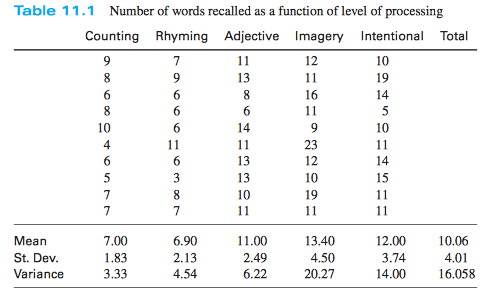

However, the data in our `dataset` in long format. This is the preferred format for both `R` and `SPSS`. If you originally get data in the wide format you will need to convert it to the long format using `gather()` (see my own brief tutorial on gathering data [here](https://tehjespah.github.io/teaching/PSYC7014/LevelingUp/PlottingData/bars_and_boxplots/)).

## Assumptions for ANOVA

Here, I am assuming that you have already checked our assumptions related to the normality of the data. Another assumption of ANOVA is the homogeneity of variance between groups. An easy-way to get an eyeball test of this assumption is two perform a box plot of the data. Here I am performing this plot using `ggplot2`:

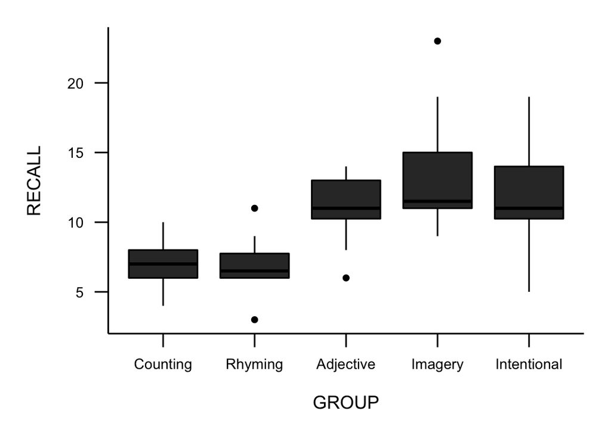

```r
boxplots <- ggplot(data = dataset_names, aes(x=GROUP,y=RECALL)) +
  geom_boxplot()

show(boxplots)
```

Huge differences in the shaded IQR regions may be a clue that the homogeneity assumption is violated. We can run even more specific tests in `R` including the Bartlett Test (parametric) and Figner-Killeen (non-parametric) Test of Homogeneity of Variances. As is typically the case $p<.05$ indicates a violation of this assumption:

```r
# Bartlett Test of Homogeneity of Variances
bartlett.test(RECALL~GROUP, data=dataset_names)
```

```
##
##  Bartlett test of homogeneity of variances
##
## data:  RECALL by GROUP
## Bartlett's K-squared = 9.9339, df = 4, p-value = 0.04156
```

```r
# Figner-Killeen Test of Homogeneity of Variances
fligner.test(RECALL~GROUP, data=dataset_names)
```

```
##
##  Fligner-Killeen test of homogeneity of variances
##
## data:  RECALL by GROUP
## Fligner-Killeen:med chi-squared = 1.9733, df = 4, p-value = 0.7407
```

## Running an ANOVA in R:

From here, we may perform our ANOVA using the `aov()`. Like `lm()` from last week `aov()` asks us to enter our dependent and independent variables into the model in the formula format **DV ~ IVs**. In this case, we only have a single IV, `GROUP`. Thus our model is:

```r
aov.model <- aov(RECALL~GROUP,data = dataset_names)
```

From here, a `summary()` of the model gives us our ANOVA table.

```r
summary(aov.model)
```

```
##             Df Sum Sq Mean Sq F value   Pr(>F)
## GROUP        4  351.5   87.88   9.085 1.82e-05 ***
## Residuals   45  435.3    9.67
## ---
## Signif. codes:  0 '***' 0.001 '**' 0.01 '*' 0.05 '.' 0.1 ' ' 1
```

```r
attributes(aov.model)
```

```
## $names
##  [1] "coefficients"  "residuals"     "effects"       "rank"
##  [5] "fitted.values" "assign"        "qr"            "df.residual"
##  [9] "contrasts"     "xlevels"       "call"          "terms"
## [13] "model"
##
## $class
## [1] "aov" "lm"
```

## Reporting your data

First let’s grab the descriptive stats:

```r
describeBy(dataset_names$RECALL,dataset_names$GROUP)
```

```
##
##  Descriptive statistics by group
## group: Counting
##    vars  n mean   sd median trimmed  mad min max range skew kurtosis   se
## X1    1 10    7 1.83      7       7 1.48   4  10     6    0    -1.22 0.58
## --------------------------------------------------------
## group: Rhyming
##    vars  n mean   sd median trimmed  mad min max range skew kurtosis   se
## X1    1 10  6.9 2.13    6.5    6.88 0.74   3  11     8 0.18     -0.4 0.67
## --------------------------------------------------------
## group: Adjective
##    vars  n mean   sd median trimmed  mad min max range  skew kurtosis   se
## X1    1 10   11 2.49     11   11.25 2.97   6  14     8 -0.66    -0.84 0.79
## --------------------------------------------------------
## group: Imagery
##    vars  n mean  sd median trimmed  mad min max range skew kurtosis   se
## X1    1 10 13.4 4.5   11.5   12.75 1.48   9  23    14 0.99    -0.53 1.42
## --------------------------------------------------------
## group: Intentional
##    vars  n mean   sd median trimmed  mad min max range skew kurtosis   se
## X1    1 10   12 3.74     11      12 2.97   5  19    14 0.05    -0.47 1.18
```

### Reporting in the text

Reporting the omnibus ANOVA includes:

- **the F value**,
- **the degress of freedom (between and within)**,
- **the p-value**
- **effect size**: typically with ANOVA we report partial eta squared, although note that Howell advocates for omega squared. Howell gives you the equations to calculate both; and indeed they can be calculated given the info that is conveyed in the `summary(aov)` output. I won’t delve too much into the how to do that here, because, well… homework. But it should be included.

For our data our report takes the form: $F(4,45)=9.085,p<.001, \eta_p^2=.45$.

As we typically focus on means with ANOVA, it is typically a good idea to report means and some report of of the distribution of each group (typically either standard deviation or standard error; although 95% CI may be useful in certain scenarios).

So for example reporting the Rhyming group:

- **M ± SD:** 6.90 ± 2.13
- **SE:** 6.90 ± 0.67

### What the omnibus ANOVA tells you

While it may be useful to report the means, you need to be mindful of what the omnibus ANOVA tells you. Remember, that the the null hypothesis of the omnibus ANOVA is that “there are no differences between observed means”. Our significant result tells us that there *are* differences between our means, **but does not tell us what those specific differences are**. So while it may be useful to report general relationships, e.g., “Recall for people in the Intentional group tended to be greater than for the Counting group” you **cannot** say definitively “Recall was significantly greater for the Intentional Group”. Typically when you only have tested the omnibus ANOVA, you only speak in generalities (e.g., “Recall tended to increase with level of processing.”)

Always be mindful that you don’t over interpret your data.

### Plots

For ANOVA plots, there are typically three acceptable plots used to convey, box plots, bar plots, and line plots. As the ANOVA become more complex, we tend towards using line plots (box plots and bar plots may become very busy in complex designs). Unless there are compelling reasons not to we tend to plot the means (although note that box plots usually give you medians). Since we have already produced a box plot above, I’ll show examples of bar and line plots.

First, a **line plot** with points at the means and error lines representing the 95% CI (known as a point range):

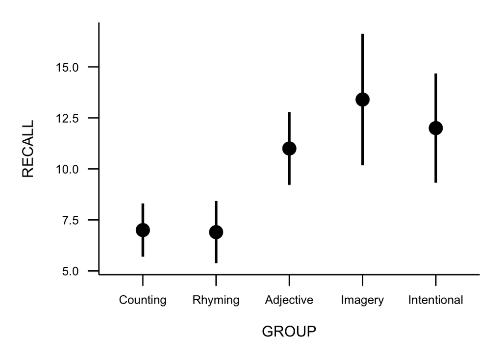

```r
p <- ggplot2::ggplot(data = dataset_names,mapping = aes(x = GROUP, y = RECALL))

# create the points
p <- p + stat_summary(fun.data = mean_cl_normal, size=1, color="black", geom="pointrange"); show(p)
```

Now to add the lines. For this you will need another `stat_summary()` line specifying that the vertices of the lines should be the means, `fun.y = mean` and a parameter that specifies how the lines should be grouped. While we’re at it let’s fix those axes titles. We can use the functions `xlab()` and `ylab()` to do so.

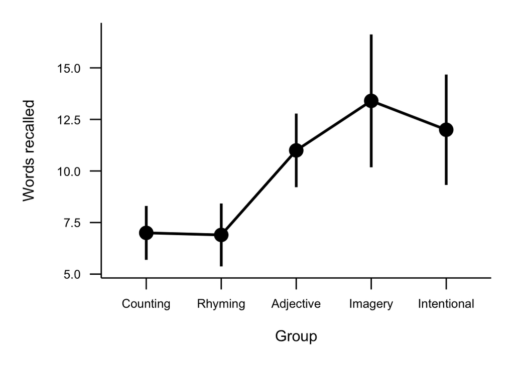

```r
# this is from before:
p <- ggplot2::ggplot(data = dataset_names,mapping = aes(x = GROUP, y = RECALL))
p <- p + stat_summary(fun.data = mean_cl_normal, size=1, color="black", geom="pointrange");

# and now adding the lines
p <- p + stat_summary(data=dataset_names, fun.y = mean, size = 1, color = "black", mapping=aes(group=1), geom="line")

# and fixing the axis titles:
p <- p + xlab("Group")+ylab("Words recalled")

show(p)
```

Now a **bar plot**, with standard error bars:

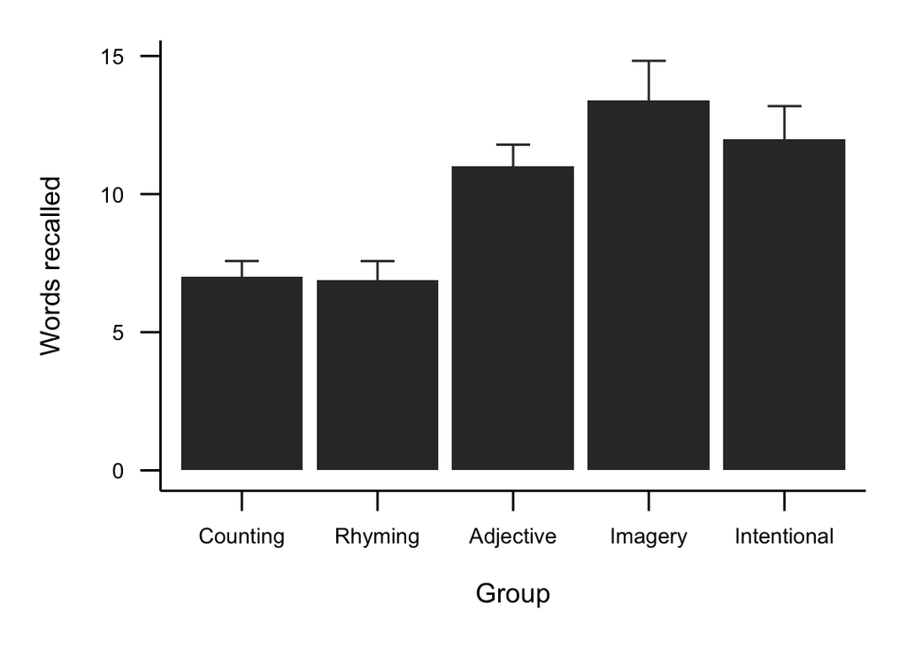

```r
p <- ggplot2::ggplot(data = dataset_names,mapping = aes(x = GROUP, y = RECALL))
p <- p + stat_summary(fun.y = mean, geom = "bar");
p <- p + stat_summary(fun.data = mean_se, geom = "errorbar", aes(width=.25))
p <- p + xlab("Group")+ylab("Words recalled")

show(p)
```

and fixing the gap below the zero:

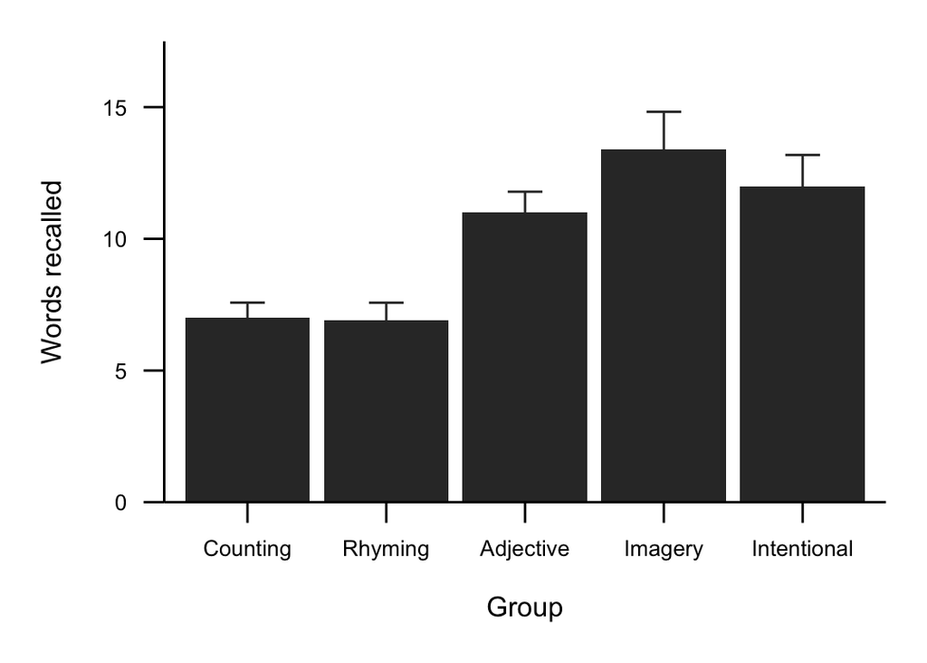

```r
# fixing gap below zero:
p <- p + scale_y_continuous(expand = c(0,0)) + expand_limits(y=c(0,17.5))

show(p)
```

Note that when you present a figure, (A) **you need to refer to the figure in the text** and (B) you need to provide a figure caption that gives adequate detail. The caption should go below the figure:

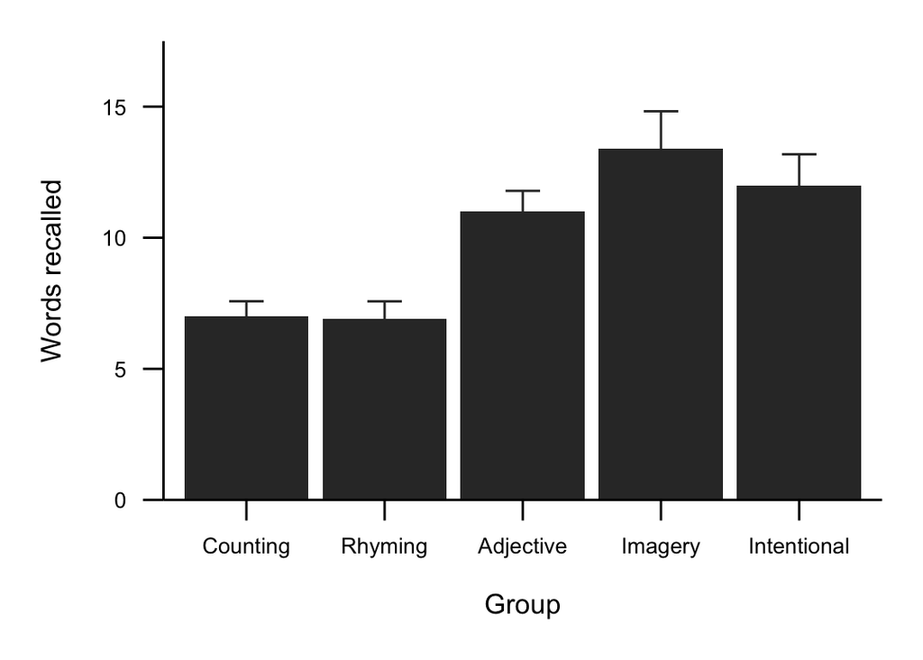

```r
show(p)
```

*Figure 1*. Mean words recalled as a function of learning group. Error bars represent standard error.

# DIGGING DEEPER

Now that we’ve got practical matters out of the way, I want to take some time to dig a little deeper into the connections between ANOVA this week and our work on correlations and regressions in the past.

## `aov()` v. `lm()`

As we’ve already mentioned (and spent time discussing in class) ANOVA is just an extension of the simple linear model that we covered last week, where ANOVA is used when our predictors are discrete. In fact `aov()` is simply a wrapper for the `lm()` function that we used last week. If you were to look at what is going on “underneath the hood” you would see this when you call `aov()`:

```r
lm.model <- lm(RECALL~GROUP, data=dataset_names)
anova(lm.model)
```

```
## Analysis of Variance Table
##
## Response: RECALL
##           Df Sum Sq Mean Sq F value    Pr(>F)
## GROUP      4 351.52  87.880  9.0848 1.815e-05 ***
## Residuals 45 435.30   9.673
## ---
## Signif. codes:  0 '***' 0.001 '**' 0.01 '*' 0.05 '.' 0.1 ' ' 1
```

That is, all `aov()` does is take an `lm` object and produce an ANOVA table from the results. If we were simply to look at the `lm() model` we see that it gives us our ANOVA table in the summary:

```r
lm(RECALL~GROUP, data=dataset_names) %>% summary()
```

```
##
## Call:
## lm(formula = RECALL ~ GROUP, data = dataset_names)
##
## Residuals:
##    Min     1Q Median     3Q    Max
##  -7.00  -1.85  -0.45   2.00   9.60
##
## Coefficients:
##                  Estimate Std. Error t value Pr(>|t|)
## (Intercept)        7.0000     0.9835   7.117 6.83e-09 ***
## GROUPRhyming      -0.1000     1.3909  -0.072 0.943004
## GROUPAdjective     4.0000     1.3909   2.876 0.006138 **
## GROUPImagery       6.4000     1.3909   4.601 3.43e-05 ***
## GROUPIntentional   5.0000     1.3909   3.595 0.000802 ***
## ---
## Signif. codes:  0 '***' 0.001 '**' 0.01 '*' 0.05 '.' 0.1 ' ' 1
##
## Residual standard error: 3.11 on 45 degrees of freedom
## Multiple R-squared:  0.4468, Adjusted R-squared:  0.3976
## F-statistic: 9.085 on 4 and 45 DF,  p-value: 1.815e-05
```

Taking a look at this output, we see that the `lm() model` also gives us a lot of other additional useful info. For example the $R^2$ of the model may be understood as the effect size of the ANOVA. However, when we report it for ANOVA we express it as *partial eta-squared*, or $\eta_p^2$.

Zooming in on the coefficients:

```
##                  Estimate Std. Error     t value     Pr(>|t|)
## (Intercept)           7.0  0.9835311  7.11721300 6.830993e-09
## GROUPRhyming         -0.1  1.3909230 -0.07189471 9.430043e-01
## GROUPAdjective        4.0  1.3909230  2.87578833 6.137702e-03
## GROUPImagery          6.4  1.3909230  4.60126133 3.425167e-05
## GROUPIntentional      5.0  1.3909230  3.59473541 8.019114e-04
```

We see information about the means of each group relative to the (Intercept). This is way I stressed earlier that it may be useful to rearrange the order of your levels such that `R` enters your control group into the model first. In this case, the first predictor entered is assigned to the (Intercept). The remaining predictors in the model are then presented relative to the first. Since we entered “Counting” first, the estimate of the (Intercept) represents its mean. The means for each remaining group are the sum of its estimate coefficient and the (Intercept). So for example the mean of the Rhyming group is $(-0.1)+(7.0)=6.9$.

The coefficients section also gives us one other useful bit of information, the *t*-values of the estimate. As we learned last week, for a simple regression the beta coefficient gives us information about the slope of the regression line and the corresponding *t*-value is a test of the null $beta=0$. So for a simple regression this tells us if our slope is significantly different from 0.

A similar logic applies to the ANOVA model. As I mentioned above, deriving the means of each of our IVs is a matter of summing the (Intercept) and the beta estimate for that IV. It should be apparent, then that the beta estimates here represent the slope of a line that between the intercept and the mean of the IV. Therefore, a significant *t*-value for beta tells us that the slope between the two means is significant, or that those two means are significantly different from one another. Keep in mind the only comparisons that are been made here are between the individual IVs and the control (Intercept). So while this output allows us to make a claim about the difference between the means of the Counting (Intercept) group compared to each of the other groups, it **does not** allow us to make a claim about differences between our other IVs—for example no information about a statistical test of differences between the Rhyming and Imagery groups is conveyed here. However, assuming you are interested in deviations from your control, you can get info here quickly.

## Regression method v. means method

By now you may ask: “Well, if ANOVA is simply linear regression then why involve different functions?” You may even note (and be peeved about the fact) that last week we derived the *F* ratio using an entirely different equation than was used this week, even though the both equations yield the same result! Why!!!!!

Sadly, tradition and convention are all I can tell you. While in both cases the *F-value* is an expression of amount of varience that your model (`lm` or `aov`) explains, in the ANOVA case we are concerned with the means of discrete groups or IVs. Since `lm` deals with continuous predictors (or IVs) then it makes little since to talk about means, other than the grand mean. In both instances, however, the derived F is an expression of the model’s fit.

My goal for this section is to demonstrate to you that the regression method we used to derive the the *F* ratio last week is identical to the means method Howell introduced you to this week. First to recap the regression method, our equation from last week’s slides was:

$$F=\frac{r^2 / df_{reg}}{(1-r^2)/df_{res}}$$

- where $r^2$ is the model’s coefficient of determination
- $df_{reg}$: the model’s $df$ (based on # of predictors), and
- $df_{res}$: the model’s residual $df$

moreover,

$$r^2=\frac{SS_Y-SS_{res}}{SS_Y}$$

- where $SS_Y$ is the sum of squared differences between the observed values $Y$ and the grand mean $\bar{Y}$
- $SS_{res}$ is the sum of squared differences between the observed values $Y$ and the model-predicted values $\hat{Y}$ (or distance to regression line)

$r^2$ is simply a statment about the difference in the grand mean and best fit residuals as a percentage of $SS_Y$.

The same applies for ANOVA with one crucial difference. We are dealing with discrete predictors rather than continuous. Visually, as you can see below the data are collapsed into columns, with the mean of each group located at the center of the columns’ density. This also means that rather than a continuous range of predicted values $\hat{Y}$ we have a set number of $\hat{Y}$, one for each group that we are considering in the ANOVA. Therefore, - $SS_Y$ may be thought of in terms of the differences between every score compared to the grand mean. - $SS_{res}$ may be thought of as the differences between every score within the group and the predicted mean $\hat{Y}$

Lets look at this with our ANOVA data (note that x-axis has dummy codes rather than names):

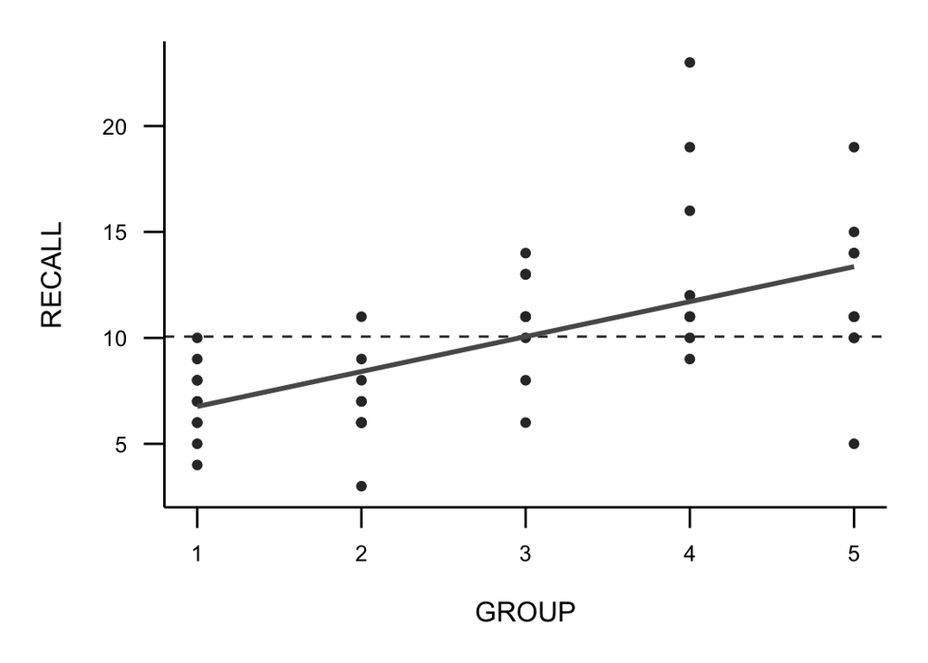

```r
p <- ggplot(data = dataset_dc,mapping = aes(x = GROUP, y = RECALL)) +
  geom_point()
p <- p + geom_hline(yintercept = mean(dataset_dc$RECALL), linetype="dashed")
p <- p + geom_smooth(method="lm", level=0.95, se = FALSE)
#p <- p + stat_summary(fun.data = mean_se, size=1, color="red", geom="pointrange")
show(p)
```

Now lets turn to our *F*-ratio equation from Howell:

$$F=\frac{MS_{treat}}{MS_{error}}$$

where

- $MS_{error}$ = $SS_{res}/df_{res}$
- and $MS_{treat}$ = ($(SS_{Y}-SS_{res})/df_{reg}$;

note that $df_{res}$ may be calculated as $k(n-1)$ where $k$ is the number of IV and $n$ is the number of scores in each group; $df_{reg}$ is $k-1$.

so for our model, `lm.model`:

```r
SS_Y <- ((dataset_names$RECALL-mean(dataset_names$RECALL))^2) %>% sum()
SS_res <- (lm.model$residuals^2) %>% sum()

k <- 5
n <- 10

df_res <- k*(n-1)
df_reg <- k-1
MS_error <- SS_res/df_res
MS_treat <- (SS_Y-SS_res)/df_reg

F.ratio <- (MS_treat/MS_error) %>% print()
```

```
## [1] 9.084769
```

## Bringing it together: it’s all about the residuals, baby

So on one hand we have the *F*-ratio being calculated using $r^2$ and on the other we have it being calculated using the mean square. Underlying both is a calculation of various $SS$ and it is using this fact that we can show that the two methods are equivalent. Drawn out, we have:

$$F=\frac{r^2 / df_{reg}}{(1-r^2)/df_{res}} =\frac{MS_{treat}}{MS_{error}}$$

rewriting our $r^2$ in terms of $SS$ we get:

$$\frac{\frac{SS_Y-SS_{res}}{SS_Y} / df_{reg}}{(1-\frac{SS_Y-SS_{res}}{SS_Y})/df_{res}} =\frac{MS_{treat}}{MS_{error}}$$

and rewriting our $MS$ side of the equation:
$$\frac{\frac{SS_Y-SS_{res}}{SS_Y} / df_{reg}}{(1-\frac{SS_Y-SS_{res}}{SS_Y})/df_{res}} =\frac{(SS_{Y}-SS_{res})/df_{reg}}{SS_{res}/df_{res}}$$

multiplying the left side of the equation by $\frac{SS_Y}{SS_Y}$:

$$\frac{(SS_Y-SS_{res}) / df_{reg}}{(SS_Y-(SS_Y-SS_{res}))/df_{res}} =\frac{(SS_{Y}-SS_{res})/df_{reg}}{SS_{res}/df_{res}}$$

which gives us:

$$\frac{(SS_{Y}-SS_{res})/df_{reg}}{SS_{res}/df_{res}}=\frac{(SS_{Y}-SS_{res})/df_{reg}}{SS_{res}/df_{res}}$$
What does this mean for you… well perhaps nothing. Honestly, if you are using your computer for stats a correct calculation is a correct calculation. However, conceptually it may be easier to get and keep yourself in general linear model mode, as it will make incorporating more complex modeling techniques (higher-order ANOVA, ANCOVA, mixed-models, multi-level models, growth curve models) a more intuitive step in the future.